# Predict the manner of the exercise

Anand Kumar Subramaniam

February 28, 2017

### Introduction

In this project, the data from accelerometers on the belt, forearm, arm, and dumbell of 6 participants (wearables) are used. The goal of the project is to predict the manner in which the participants did the exercise. This is the “classe” variable in the training set.

### STEP1: Load the necessary libraries

```r
  library(caret)
  library(ggplot2)
  library(dplyr)
  library(rattle)
  library(corrplot)
  library(rpart)
  library(rpart.plot)
```

### STEP 2: Read the training and testing Data

```r
    TrainingSet_org <-   read.csv("pml-training.csv",na.strings=c("", "NA", "NULL"))
    PredictSet <- read.csv("pml-testing.csv", na.strings=c("", "NA", "NULL"))

    dim(TrainingSet_org)
```

```
## [1] 19622   160
```

```r
    dim(PredictSet)
```

```
## [1]  20 160
```

### STEP 3: Preprocess the data

```r
    #. 1.Remove columns that has  NA Values
    New_TrainingSet <- TrainingSet_org[, colSums(is.na(TrainingSet_org))==0]
    dim(New_TrainingSet)
```

```
## [1] 19622    60
```

```r
    # New Training set has only 60 columns.
    remove(TrainingSet_org)

    # colnames(New_TrainingSet)
    # 2. Remove  unnecessary predictors which are not related to the outcome Classe like the     #    following Predictors
      # 1. X
      # 2. "user_name"
      # 3. raw_timestamp_part_1
      # 4. raw_timestamp_part_2
      # 5. cvtd_timestamp
      # 6. new_window
      # 7. num_window
     New_TrainingSet <- New_TrainingSet[,-(1:7)]
    dim(New_TrainingSet)
```

```
## [1] 19622    53
```

```r
    # New Training set has only 53 columns.

    # check for variables that have very low variance.
    # NonZeroVar Predictors: Remove predictors that have one unique value across samples (zero variance predictors).          # Function used is Caret NonZeroVar which removes predictors that have both
    # 1) few unique values relative to the number of samples and
    # 2) large ratio of the frequency of the most common value to the frequency of the second most common value (near-zero     #    variance predictors).
    Zero_Variance = nearZeroVar(New_TrainingSet, saveMetrics = TRUE)
    summary(Zero_Variance) # understand the  structure of Zero_variance results
```

```
##    freqRatio      percentUnique       zeroVar           nzv
##  Min.   : 1.000   Min.   : 0.02548   Mode :logical   Mode :logical
##  1st Qu.: 1.036   1st Qu.: 1.41678   FALSE:53        FALSE:53
##  Median : 1.079   Median : 3.27693   NA's :0         NA's :0
##  Mean   : 6.002   Mean   : 8.88241
##  3rd Qu.: 1.140   3rd Qu.: 7.76679
##  Max.   :87.256   Max.   :84.20650
```

```r
    Zero_Variance[Zero_Variance[, 'nzv'] > 0, ]
```

```
## [1] freqRatio     percentUnique zeroVar       nzv
## <0 rows> (or 0-length row.names)
```

```r
    New_TrainingSet_nzv = New_TrainingSet[,Zero_Variance[, 'nzv']==0]
    dim(New_TrainingSet_nzv)
```

```
## [1] 19622    53
```

```r
    # No predictors were eliminated based on Non-Zero Variance effort.
```

### STEP 4: Find and remove Highly correlated predictors

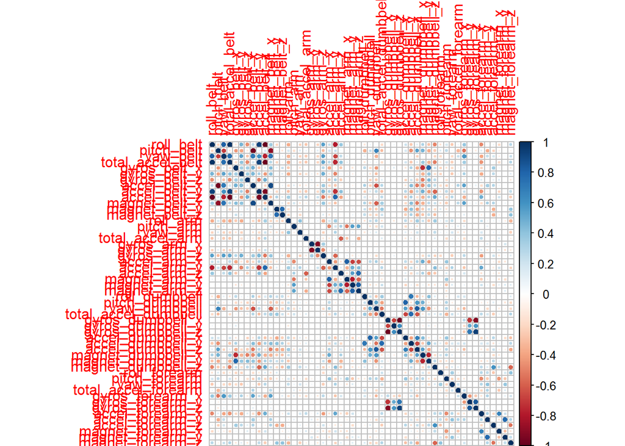

```r
    CorPredictors <- cor(na.omit(New_TrainingSet_nzv[, -which(names(New_TrainingSet_nzv) %in% c("classe"))]))

    # Plot the Correlation


    corrplot( CorPredictors , method="circle")
```

```r
    RemovePredictors = findCorrelation(CorPredictors, cutoff = .90, verbose = TRUE)
```

```
## Compare row 10  and column  1 with corr  0.992
##   Means:  0.27 vs 0.168 so flagging column 10
## Compare row 1  and column  9 with corr  0.925
##   Means:  0.25 vs 0.164 so flagging column 1
## Compare row 9  and column  4 with corr  0.928
##   Means:  0.233 vs 0.161 so flagging column 9
## Compare row 8  and column  2 with corr  0.966
##   Means:  0.245 vs 0.157 so flagging column 8
## Compare row 19  and column  18 with corr  0.918
##   Means:  0.091 vs 0.158 so flagging column 18
## Compare row 46  and column  31 with corr  0.914
##   Means:  0.101 vs 0.161 so flagging column 31
## Compare row 46  and column  33 with corr  0.933
##   Means:  0.083 vs 0.164 so flagging column 33
## All correlations <= 0.9
```

```r
    # Names of the Predictors that are highly correlated > 90%
    colnames(New_TrainingSet_nzv[,RemovePredictors])
```

```
## [1] "accel_belt_z"     "roll_belt"        "accel_belt_y"
## [4] "accel_belt_x"     "gyros_dumbbell_x" "gyros_dumbbell_z"
## [7] "gyros_arm_x"
```

```r
    # Remove the highly correlated predictors from the trainingset.
    New_TrainingSet_nzv_cor = New_TrainingSet_nzv[,-RemovePredictors]

    # Final cleaned Training Set
    dim(New_TrainingSet_nzv_cor)
```

```
## [1] 19622    46
```

```r
    #head(New_TrainingSet_nzv_cor)
```

### STEP 5: Create Training and Test data partition.

```r
    inTrain <- createDataPartition (y=New_TrainingSet_nzv_cor$classe, p=0.7, list=FALSE) #Create Partition
    TrainingSet <- New_TrainingSet_nzv_cor[inTrain,] # 70% Training
    TestingSet <- New_TrainingSet_nzv_cor[-inTrain,] # 30% Testing.
```

The **TrainingSet** consist of **13737 samples** and **46 variables**.

The **TestingSet** consist of **5885 samples** and **46 variables**.

### STEP 6: Model Analysis.

```r
  set.seed(1)
  # 1. Random forest
  RF_ModelFit <- train( classe~ ., data = TrainingSet, method ="rf", maxdepth=100  )
  RF_ModelFit$finalModel
```

```
##
## Call:
##  randomForest(x = x, y = y, mtry = param$mtry, maxdepth = 100)
##                Type of random forest: classification
##                      Number of trees: 500
## No. of variables tried at each split: 23
##
##         OOB estimate of  error rate: 0.67%
## Confusion matrix:
##      A    B    C    D    E class.error
## A 3902    3    0    0    1 0.001024066
## B   24 2630    4    0    0 0.010534236
## C    0   16 2372    8    0 0.010016694
## D    0    0   24 2225    3 0.011989343
## E    0    0    2    7 2516 0.003564356
```

```r
  RF_Predict <- predict(RF_ModelFit, newdata = TestingSet)

  RF_ConfResult<- confusionMatrix(RF_Predict, TestingSet$classe)

  #2. Recursive Partitioning
  RPart_ModelFit <- train( classe~ ., data = TrainingSet, method ="rpart")
  RPart_ModelFit$finalModel
```

```
## n= 13737
##
## node), split, n, loss, yval, (yprob)
##       * denotes terminal node
##
##  1) root 13737 9831 A (0.28 0.19 0.17 0.16 0.18)
##    2) pitch_forearm< -33.95 1095    8 A (0.99 0.0073 0 0 0) *
##    3) pitch_forearm>=-33.95 12642 9823 A (0.22 0.21 0.19 0.18 0.2)
##      6) magnet_belt_y>=555.5 11605 8789 A (0.24 0.23 0.21 0.18 0.14)
##       12) magnet_dumbbell_y< 438.5 9680 6930 A (0.28 0.18 0.24 0.17 0.12)
##         24) roll_forearm< 122.5 6057 3594 A (0.41 0.17 0.18 0.14 0.092) *
##         25) roll_forearm>=122.5 3623 2396 C (0.079 0.18 0.34 0.22 0.18)
##           50) accel_forearm_x>=-103.5 2505 1545 C (0.089 0.22 0.38 0.088 0.22) *
##           51) accel_forearm_x< -103.5 1118  536 D (0.058 0.091 0.24 0.52 0.091) *
##       13) magnet_dumbbell_y>=438.5 1925  985 B (0.034 0.49 0.032 0.21 0.24) *
##      7) magnet_belt_y< 555.5 1037  183 E (0.0029 0.0029 0.0019 0.17 0.82) *
```

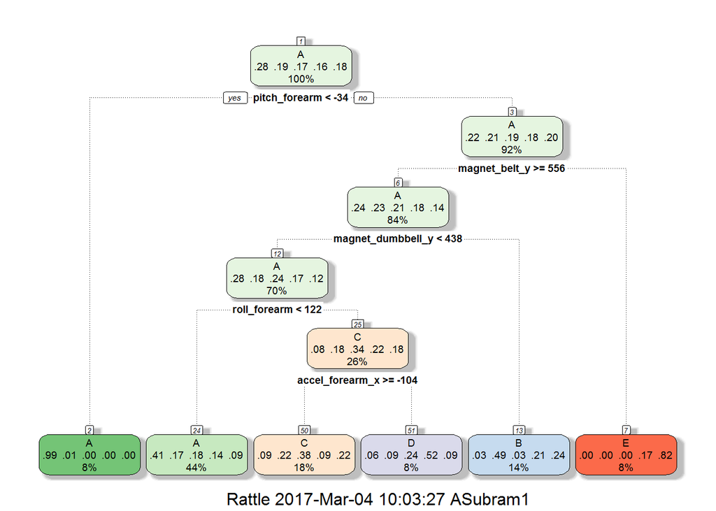

```r
  fancyRpartPlot(RPart_ModelFit$finalModel)
```

```r
  Rpart_Predict <- predict(RPart_ModelFit, newdata = TestingSet)
  Rpart_ConfResult <- confusionMatrix(Rpart_Predict, TestingSet$classe)


  #3. Try Neural network

  nnet_ModelFit <- train( classe~ ., data = TrainingSet, method ="nnet", trace =FALSE)
  nnet_ModelFit$finalModel
```

```
## a 45-5-5 network with 260 weights
## inputs: pitch_belt yaw_belt total_accel_belt gyros_belt_x gyros_belt_y gyros_belt_z magnet_belt_x magnet_belt_y magnet_belt_z roll_arm pitch_arm yaw_arm total_accel_arm gyros_arm_y gyros_arm_z accel_arm_x accel_arm_y accel_arm_z magnet_arm_x magnet_arm_y magnet_arm_z roll_dumbbell pitch_dumbbell …
## output(s): .outcome
## options were - softmax modelling  decay=1e-04
```

```r
  nnet_Predict <- predict(nnet_ModelFit, newdata = TestingSet)
  nnet_ConfResult <- confusionMatrix(nnet_Predict, TestingSet$classe)
```

### STEP 7: Compare Models Accuracy

**Random Forest** has the **accuracy** of **0.9950722** which far better than the recursive partitioning accuracy which has the accuracy of **0.4858114** and neural network’s accuracy of **0.3476636**

The **Random forest reference table** below shows the prediction using this model which shows the predictions are pretty close to actuals. **1673, 1, 0, 0, 0, 8, 1128, 2, 1, 0, 0, 6, 1018, 2, 0, 0, 1, 6, 957, 0, 0, 0, 1, 1, 1080**.

Let’s do a Repeated k-fold Cross Validation on Random Forest Accuracy

### STEP 8: Random Forest Cross Validation

Inorder to reduce the bias on few predictors, lets do a cross validation by randomly selecting the number of predictors.

```r
  # define training control
  train_control <- trainControl(method="repeatedcv", number=10, repeats=3, search="random")
  set.seed(1)

  #set grid parameter
  grid <- expand.grid(.mtry = c(1:15)) #sqrt(ncol(TrainingSet)))

  library(klaR)

  # train the model
  rf_Random_model <- train(classe ~ .,
                          data = TrainingSet,
                          metric = "Accuracy",
                          trControl=train_control,
                          tunelength=15,
                          method="rf",
                          tuneGrid=data.frame(grid))


  # summarize results
  print(rf_Random_model)
```

```
## Random Forest
##
## 13737 samples
##    45 predictor
##     5 classes: 'A', 'B', 'C', 'D', 'E'
##
## No pre-processing
## Resampling: Cross-Validated (10 fold, repeated 3 times)
## Summary of sample sizes: 12365, 12363, 12363, 12364, 12363, 12362, ...
## Resampling results across tuning parameters:
##
##   mtry  Accuracy   Kappa
##    1    0.9859750  0.9822519
##    2    0.9910709  0.9887031
##    3    0.9920415  0.9899315
##    4    0.9927452  0.9908220
##    5    0.9928906  0.9910059
##    6    0.9931333  0.9913130
##    7    0.9933760  0.9916201
##    8    0.9936428  0.9919577
##    9    0.9939097  0.9922954
##   10    0.9940310  0.9924489
##   11    0.9937883  0.9921416
##   12    0.9937396  0.9920801
##   13    0.9937639  0.9921109
##   14    0.9934971  0.9917733
##   15    0.9933272  0.9915584
##
## Accuracy was used to select the optimal model using  the largest value.
## The final value used for the model was mtry = 10.
```

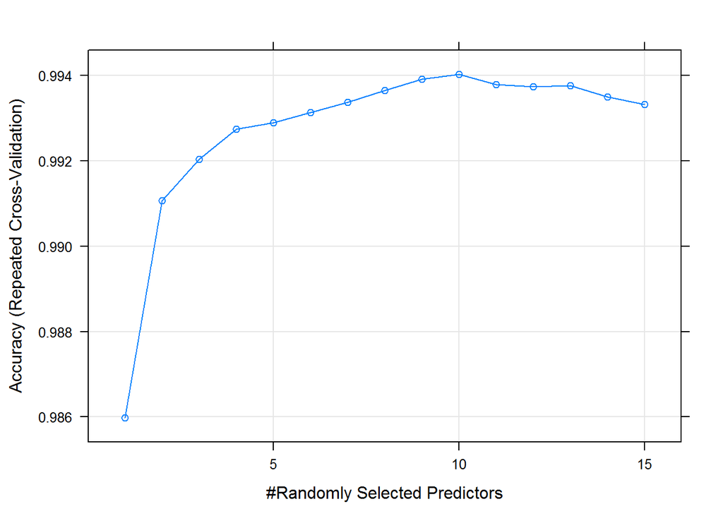

```r
  #
  plot(rf_Random_model)
```

### STEP 8: Out of Sample Error

In order to estimate the out-of-sample accuracy, we need to train the data on one dataset (which we did using the TrainingSet), and then apply it to a new dataset (which is Testing Data Set).

```r
  RF_Random_Predict <- predict(rf_Random_model, newdata = TestingSet)

  RF_Random_ConfResult<- confusionMatrix(RF_Random_Predict, TestingSet$classe)

  print(RF_Random_ConfResult)
```

```
## Confusion Matrix and Statistics
##
##           Reference
## Prediction    A    B    C    D    E
##          A 1674    5    0    0    0
##          B    0 1132    5    0    0
##          C    0    1 1019    8    1
##          D    0    0    2  955    1
##          E    0    1    0    1 1080
##
## Overall Statistics
##
##                Accuracy : 0.9958
##                  95% CI : (0.9937, 0.9972)
##     No Information Rate : 0.2845
##     P-Value [Acc > NIR] : < 2.2e-16
##
##                   Kappa : 0.9946
##  Mcnemar's Test P-Value : NA
##
## Statistics by Class:
##
##                      Class: A Class: B Class: C Class: D Class: E
## Sensitivity            1.0000   0.9939   0.9932   0.9907   0.9982
## Specificity            0.9988   0.9989   0.9979   0.9994   0.9996
## Pos Pred Value         0.9970   0.9956   0.9903   0.9969   0.9982
## Neg Pred Value         1.0000   0.9985   0.9986   0.9982   0.9996
## Prevalence             0.2845   0.1935   0.1743   0.1638   0.1839
## Detection Rate         0.2845   0.1924   0.1732   0.1623   0.1835
## Detection Prevalence   0.2853   0.1932   0.1749   0.1628   0.1839
## Balanced Accuracy      0.9994   0.9964   0.9956   0.9950   0.9989
```

### Conclusion

Using the Random forest model, predict the values for the PredictSet part of pml-testing.csv. Apply the Random forest model with predict data set to predict function. The results are as shown.

```r
  Predict_Results <- predict(rf_Random_model,newdata = PredictSet)
  Predict_Results
```

```
##  [1] B A B A A E D B A A B C B A E E A B B B
## Levels: A B C D E
```